# Lab 04: KNN Classification

Amogh Sahore  
2547108  
Machine Learning

## Aim

To implement KNN classification on the breast cancer dataset and analyse model performance using train-test split, heuristic K selection, cross-validation, ROC-AUC, and classification metrics. Also, to compare classification metrics with regression metrics studied in Linear Regression.

## Dataset

Breast Cancer Wisconsin Diagnostic dataset is used. The dataset has 569 records, 30 numerical features and one target column.

Target used here:

- `0` = Malignant
- `1` = Benign

## Problem Statement

A healthcare analytics team needs a KNN model for early cancer detection. The model has to be tested using different splits, K values, cross-validation and classification metrics.

## Task 1: Data Preparation

Load the dataset, check its structure, missing values and duplicates. Apply feature scaling because KNN is distance based.

```python
import numpy as np
import pandas as pd
import matplotlib.pyplot as plt

from sklearn.model_selection import train_test_split, StratifiedKFold, cross_val_score
from sklearn.preprocessing import StandardScaler
from sklearn.neighbors import KNeighborsClassifier
from sklearn.pipeline import Pipeline
from sklearn.metrics import (
    accuracy_score, precision_score, recall_score, f1_score,
    confusion_matrix, classification_report, roc_curve, roc_auc_score
)

pd.set_option("display.max_columns", 40)
RANDOM_STATE = 42
```

```python
df = pd.read_csv("brca.csv")
df = df.rename(columns={df.columns[0]: "id"})

df.head()
```

|  | id | x.radius_mean | x.texture_mean | x.perimeter_mean | x.area_mean | x.smoothness_mean | x.compactness_mean | x.concavity_mean | x.concave_pts_mean | x.symmetry_mean | x.fractal_dim_mean | x.radius_se | x.texture_se | x.perimeter_se | x.area_se | x.smoothness_se | x.compactness_se | x.concavity_se | x.concave_pts_se | x.symmetry_se | x.fractal_dim_se | x.radius_worst | x.texture_worst | x.perimeter_worst | x.area_worst | x.smoothness_worst | x.compactness_worst | x.concavity_worst | x.concave_pts_worst | … |
| --- | --- | --- | --- | --- | --- | --- | --- | --- | --- | --- | --- | --- | --- | --- | --- | --- | --- | --- | --- | --- | --- | --- | --- | --- | --- | --- | --- | --- | --- | --- |
| 0 | 1 | 13.540 | 14.36 | 87.46 | 566.3 | 0.09779 | 0.08129 | 0.06664 | 0.047810 | 0.1885 | 0.05766 | 0.2699 | 0.7886 | 2.058 | 23.560 | 0.008462 | 0.014600 | 0.02387 | 0.013150 | 0.01980 | 0.002300 | 15.110 | 19.26 | 99.70 | 711.2 | 0.14400 | 0.17730 | 0.23900 | 0.12880 | … |
| 1 | 2 | 13.080 | 15.71 | 85.63 | 520.0 | 0.10750 | 0.12700 | 0.04568 | 0.031100 | 0.1967 | 0.06811 | 0.1852 | 0.7477 | 1.383 | 14.670 | 0.004097 | 0.018980 | 0.01698 | 0.006490 | 0.01678 | 0.002425 | 14.500 | 20.49 | 96.09 | 630.5 | 0.13120 | 0.27760 | 0.18900 | 0.07283 | … |
| 2 | 3 | 9.504 | 12.44 | 60.34 | 273.9 | 0.10240 | 0.06492 | 0.02956 | 0.020760 | 0.1815 | 0.06905 | 0.2773 | 0.9768 | 1.909 | 15.700 | 0.009606 | 0.014320 | 0.01985 | 0.014210 | 0.02027 | 0.002968 | 10.230 | 15.66 | 65.13 | 314.9 | 0.13240 | 0.11480 | 0.08867 | 0.06227 | … |
| 3 | 4 | 13.030 | 18.42 | 82.61 | 523.8 | 0.08983 | 0.03766 | 0.02562 | 0.029230 | 0.1467 | 0.05863 | 0.1839 | 2.3420 | 1.170 | 14.160 | 0.004352 | 0.004899 | 0.01343 | 0.011640 | 0.02671 | 0.001777 | 13.300 | 22.81 | 84.46 | 545.9 | 0.09701 | 0.04619 | 0.04833 | 0.05013 | … |
| 4 | 5 | 8.196 | 16.84 | 51.71 | 201.9 | 0.08600 | 0.05943 | 0.01588 | 0.005917 | 0.1769 | 0.06503 | 0.1563 | 0.9567 | 1.094 | 8.205 | 0.008968 | 0.016460 | 0.01588 | 0.005917 | 0.02574 | 0.002582 | 8.964 | 21.96 | 57.26 | 242.2 | 0.12970 | 0.13570 | 0.06880 | 0.02564 | … |

```python
print("Shape:", df.shape)
print("Missing values:", df.isnull().sum().sum())
print("Duplicate rows:", df.duplicated().sum())
print("Target values:")
print(df["y"].value_counts())
```

```
Shape: (569, 32)
Missing values: 0
Duplicate rows: 0
Target values:
y
B    357
M    212
Name: count, dtype: int64
```

```python
df["target"] = df["y"].map({"M": 0, "B": 1})

X = df.drop(columns=["id", "y", "target"])
y = df["target"]

print("Feature shape:", X.shape)
print("Target shape:", y.shape)
```

```
Feature shape: (569, 30)
Target shape: (569,)
```

**Inference:** The data has no missing values. The target is converted into numeric form. Scaling is needed because KNN calculates distance, so large-value features can dominate small-value features.

## Task 2: Train-Test Split Analysis

Use 80:20, 70:30 and 90:10 splits and compare performance.

```python
def make_knn(k):
    return Pipeline([
        ("scaler", StandardScaler()),
        ("knn", KNeighborsClassifier(n_neighbors=k))
    ])

def malignant_scores(y_true, y_pred):
    return {
        "accuracy": accuracy_score(y_true, y_pred),
        "precision_malignant": precision_score(y_true, y_pred, pos_label=0),
        "recall_malignant": recall_score(y_true, y_pred, pos_label=0),
        "f1_malignant": f1_score(y_true, y_pred, pos_label=0)
    }

split_rows = []

for test_size in [0.20, 0.30, 0.10]:
    X_train, X_test, y_train, y_test = train_test_split(
        X, y, test_size=test_size, stratify=y, random_state=RANDOM_STATE
    )
    k = round(np.sqrt(len(X_train)))
    if k % 2 == 0:
        k += 1

    model = make_knn(k)
    model.fit(X_train, y_train)
    y_pred = model.predict(X_test)

    row = {
        "split": f"{int((1-test_size)*100)}:{int(test_size*100)}",
        "train_size": len(X_train),
        "test_size": len(X_test),
        "k_used": k
    }
    row.update(malignant_scores(y_test, y_pred))
    split_rows.append(row)

split_results = pd.DataFrame(split_rows)
split_results
```

|  | split | train_size | test_size | k_used | accuracy | precision_malignant | recall_malignant | f1_malignant |
| --- | --- | --- | --- | --- | --- | --- | --- | --- |
| 0 | 80:20 | 455 | 114 | 21 | 0.964912 | 1.0 | 0.904762 | 0.95000 |
| 1 | 70:30 | 398 | 171 | 21 | 0.947368 | 1.0 | 0.859375 | 0.92437 |
| 2 | 90:10 | 512 | 57 | 23 | 0.982456 | 1.0 | 0.952381 | 0.97561 |

**Inference:** The scores may change slightly when the split changes because the training and testing samples are different. A single split is useful, but it is not enough to fully judge the model.

## Task 3: KNN Model with Heuristic K Selection

Use `K = sqrt(n)` as the first K value, then check nearby K values. Also compare distance metrics and plot decision boundaries.

```python
X_train, X_test, y_train, y_test = train_test_split(
    X, y, test_size=0.20, stratify=y, random_state=RANDOM_STATE
)

heuristic_k = round(np.sqrt(len(X_train)))
if heuristic_k % 2 == 0:
    heuristic_k += 1

print("Training samples:", len(X_train))
print("Heuristic K:", heuristic_k)
```

```
Training samples: 455
Heuristic K: 21
```

```python
k_values = list(range(max(1, heuristic_k - 5), heuristic_k + 6))
k_rows = []

for k in k_values:
    model = make_knn(k)
    model.fit(X_train, y_train)
    y_pred = model.predict(X_test)
    k_rows.append({
        "k": k,
        "accuracy": accuracy_score(y_test, y_pred),
        "recall_malignant": recall_score(y_test, y_pred, pos_label=0),
        "f1_malignant": f1_score(y_test, y_pred, pos_label=0)
    })

k_results = pd.DataFrame(k_rows)
k_results
```

|  | k | accuracy | recall_malignant | f1_malignant |
| --- | --- | --- | --- | --- |
| 0 | 16 | 0.973684 | 0.952381 | 0.963855 |
| 1 | 17 | 0.982456 | 0.952381 | 0.975610 |
| 2 | 18 | 0.982456 | 0.952381 | 0.975610 |
| 3 | 19 | 0.973684 | 0.928571 | 0.962963 |
| 4 | 20 | 0.973684 | 0.928571 | 0.962963 |
| 5 | 21 | 0.964912 | 0.904762 | 0.950000 |
| 6 | 22 | 0.964912 | 0.904762 | 0.950000 |
| 7 | 23 | 0.956140 | 0.880952 | 0.936709 |
| 8 | 24 | 0.964912 | 0.904762 | 0.950000 |
| 9 | 25 | 0.964912 | 0.904762 | 0.950000 |
| 10 | 26 | 0.956140 | 0.904762 | 0.938272 |

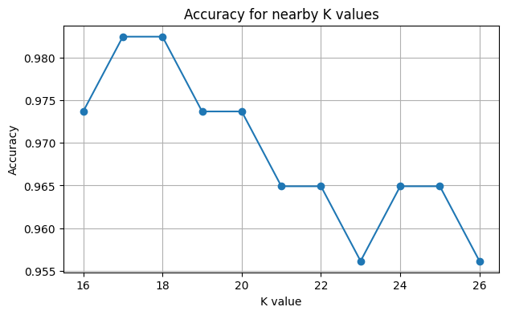

```python
plt.figure(figsize=(7, 4))
plt.plot(k_results["k"], k_results["accuracy"], marker="o")
plt.xlabel("K value")
plt.ylabel("Accuracy")
plt.title("Accuracy for nearby K values")
plt.grid(True)
plt.show()
```

```python
metric_rows = []

for metric in ["euclidean", "manhattan"]:
    model = Pipeline([
        ("scaler", StandardScaler()),
        ("knn", KNeighborsClassifier(n_neighbors=heuristic_k, metric=metric))
    ])
    model.fit(X_train, y_train)
    y_pred = model.predict(X_test)
    metric_rows.append({
        "metric": metric,
        "accuracy": accuracy_score(y_test, y_pred),
        "recall_malignant": recall_score(y_test, y_pred, pos_label=0),
        "f1_malignant": f1_score(y_test, y_pred, pos_label=0)
    })

pd.DataFrame(metric_rows)
```

|  | metric | accuracy | recall_malignant | f1_malignant |
| --- | --- | --- | --- | --- |
| 0 | euclidean | 0.964912 | 0.904762 | 0.950000 |
| 1 | manhattan | 0.947368 | 0.904762 | 0.926829 |

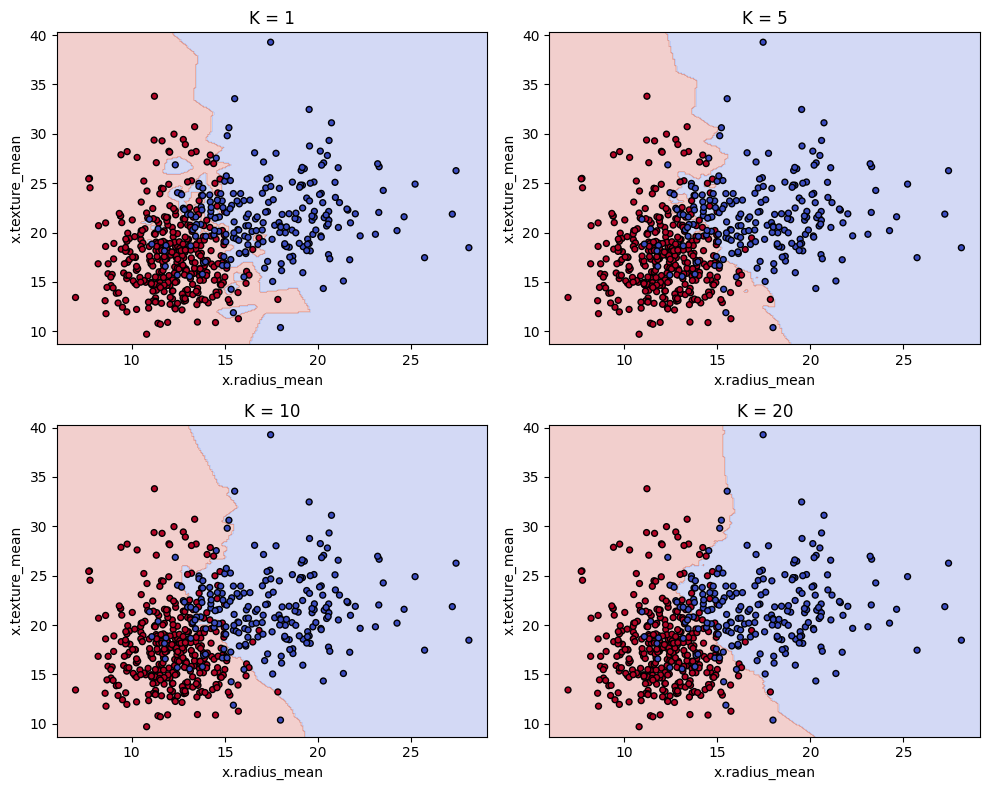

```python
boundary_features = ["x.radius_mean", "x.texture_mean"]
X_two = X[boundary_features]

x_min, x_max = X_two.iloc[:, 0].min() - 1, X_two.iloc[:, 0].max() + 1
y_min, y_max = X_two.iloc[:, 1].min() - 1, X_two.iloc[:, 1].max() + 1
xx, yy = np.meshgrid(
    np.linspace(x_min, x_max, 250),
    np.linspace(y_min, y_max, 250)
)
grid = pd.DataFrame(np.c_[xx.ravel(), yy.ravel()], columns=boundary_features)

fig, axes = plt.subplots(2, 2, figsize=(10, 8))

for ax, k in zip(axes.ravel(), [1, 5, 10, 20]):
    model = make_knn(k)
    model.fit(X_two, y)
    Z = model.predict(grid).reshape(xx.shape)

    ax.contourf(xx, yy, Z, alpha=0.25, cmap="coolwarm")
    ax.scatter(X_two.iloc[:, 0], X_two.iloc[:, 1], c=y, cmap="coolwarm", s=18, edgecolor="k")
    ax.set_title(f"K = {k}")
    ax.set_xlabel(boundary_features[0])
    ax.set_ylabel(boundary_features[1])

plt.tight_layout()
plt.show()
```

**Inference:** Smaller K gives a more irregular boundary and can overfit. Larger K gives a smoother boundary but very high K can miss local patterns.

**Euclidean distance:** Straight-line distance, useful when features are continuous and scaled.

**Manhattan distance:** Sum of absolute differences, useful when movement or difference is considered feature-wise.

## Task 4: Cross Validation

Use K-Fold cross-validation and select K using average accuracy.

```python
cv = StratifiedKFold(n_splits=5, shuffle=True, random_state=RANDOM_STATE)
cv_rows = []

for k in range(1, 41, 2):
    model = make_knn(k)
    scores = cross_val_score(model, X_train, y_train, cv=cv, scoring="accuracy")
    cv_rows.append({
        "k": k,
        "mean_accuracy": scores.mean(),
        "std_accuracy": scores.std()
    })

cv_results = pd.DataFrame(cv_rows)
best_k = int(cv_results.loc[cv_results["mean_accuracy"].idxmax(), "k"])

print("Best K from CV:", best_k)
cv_results.sort_values("mean_accuracy", ascending=False).head(10)
```

```
Best K from CV: 9
```

|  | k | mean_accuracy | std_accuracy |
| --- | --- | --- | --- |
| 4 | 9 | 0.964835 | 0.014579 |
| 5 | 11 | 0.962637 | 0.017855 |
| 10 | 21 | 0.962637 | 0.014906 |
| 1 | 3 | 0.962637 | 0.008791 |
| 2 | 5 | 0.962637 | 0.011207 |
| 3 | 7 | 0.962637 | 0.020382 |
| 6 | 13 | 0.962637 | 0.020382 |
| 11 | 23 | 0.960440 | 0.014906 |
| 9 | 19 | 0.960440 | 0.016447 |
| 7 | 15 | 0.960440 | 0.016447 |

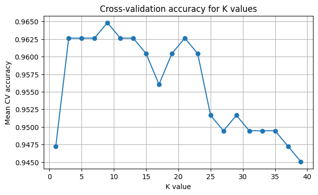

```python
plt.figure(figsize=(7, 4))
plt.plot(cv_results["k"], cv_results["mean_accuracy"], marker="o")
plt.xlabel("K value")
plt.ylabel("Mean CV accuracy")
plt.title("Cross-validation accuracy for K values")
plt.grid(True)
plt.show()
```

**Inference:** Cross-validation is better than relying on one split because every fold gets a chance to be tested. The final K is selected from the best mean CV accuracy.

## Task 5: Classification Evaluation

Evaluate the final model using accuracy, precision, recall, F1 score, confusion matrix, ROC curve and AUC.

```python
final_model = make_knn(best_k)
final_model.fit(X_train, y_train)

y_pred = final_model.predict(X_test)
malignant_index = list(final_model.named_steps["knn"].classes_).index(0)
y_score_malignant = final_model.predict_proba(X_test)[:, malignant_index]

print("Best K:", best_k)
print("Accuracy:", accuracy_score(y_test, y_pred))
print("Precision for malignant:", precision_score(y_test, y_pred, pos_label=0))
print("Recall for malignant:", recall_score(y_test, y_pred, pos_label=0))
print("F1 score for malignant:", f1_score(y_test, y_pred, pos_label=0))
print("ROC-AUC for malignant:", roc_auc_score(1 - y_test, y_score_malignant))
```

```
Best K: 9
Accuracy: 0.9736842105263158
Precision for malignant: 1.0
Recall for malignant: 0.9285714285714286
F1 score for malignant: 0.9629629629629629
ROC-AUC for malignant: 0.9943783068783068
```

```python
cm = confusion_matrix(y_test, y_pred, labels=[0, 1])
cm_df = pd.DataFrame(cm, index=["Actual M", "Actual B"], columns=["Pred M", "Pred B"])
cm_df
```

|  | Pred M | Pred B |
| --- | --- | --- |
| Actual M | 39 | 3 |
| Actual B | 0 | 72 |

```python
print(classification_report(y_test, y_pred, target_names=["Malignant", "Benign"]))
```

```
              precision    recall  f1-score   support

   Malignant       1.00      0.93      0.96        42
      Benign       0.96      1.00      0.98        72

    accuracy                           0.97       114
   macro avg       0.98      0.96      0.97       114
weighted avg       0.97      0.97      0.97       114
```

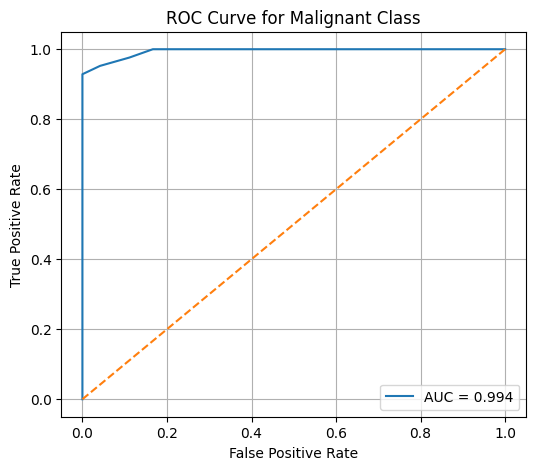

```python
fpr, tpr, thresholds = roc_curve(1 - y_test, y_score_malignant)
auc_value = roc_auc_score(1 - y_test, y_score_malignant)

plt.figure(figsize=(6, 5))
plt.plot(fpr, tpr, label=f"AUC = {auc_value:.3f}")
plt.plot([0, 1], [0, 1], linestyle="--")
plt.xlabel("False Positive Rate")
plt.ylabel("True Positive Rate")
plt.title("ROC Curve for Malignant Class")
plt.legend()
plt.grid(True)
plt.show()
```

**Inference:** In cancer prediction, recall for the malignant class is very important because missing a malignant case is more serious than wrongly flagging a benign case.

## Task 6: Comparison with Regression Metrics

| Regression metric | Classification metric | Difference |
| --- | --- | --- |
| R² score | Accuracy | R² explains fit for continuous values. Accuracy counts correct classes. |
| RMSE | F1 score | RMSE measures numeric error size. F1 balances precision and recall. |
| MAE | Confusion matrix | MAE gives average error. Confusion matrix shows correct and wrong class decisions. |

Regression metrics measure how far predicted values are from actual continuous values. Classification metrics check whether the predicted class is correct or not.

Accuracy alone is not enough in medical diagnosis because the model can still miss important malignant cases. Recall and ROC-AUC are more useful because they show how well the model identifies cancer cases and separates both classes.

## Task 7: Analytical Questions

**1. Why is KNN called a lazy learning algorithm?**  
KNN is called lazy because it does not build a proper model during training. It stores the data and does the main work during prediction.

**2. Why is feature scaling required in KNN?**  
Scaling is required because KNN uses distance. Without scaling, features with large values affect the distance more.

**3. Explain heuristic K selection using √n rule.**  
A simple starting value for K is the square root of the number of training samples. Usually an odd value is preferred to reduce ties.

**4. Why is cross-validation more reliable than a single train-test split?**  
Cross-validation tests the model on different folds, so the result does not depend only on one random split.

**5. How does K affect bias-variance trade-off?**  
Small K has low bias but high variance. Large K has more bias but lower variance.

**6. Why is recall more important than accuracy in cancer prediction?**  
Recall is important because it shows how many actual cancer cases were detected. Missing cancer cases is risky.

**7. What is the limitation of very large K values?**  
Very large K can make the model too general and it may ignore local patterns in the data.

## Conclusion

KNN was applied on the breast cancer dataset after scaling the features. The heuristic K value was used as a starting point and nearby K values were compared. Cross-validation was used to choose the final K more reliably. The final model was evaluated using accuracy, precision, recall, F1 score, confusion matrix and ROC-AUC.

For this problem, recall and ROC-AUC are more important than only accuracy because the dataset is related to medical diagnosis. Compared to regression metrics, classification metrics focus on correct class decisions instead of prediction error magnitude.